-Sviatoslav Cherniak

title: “An information theoretic quasi likelihood work through of the Parallel trends assumption”

output: html_document

date: “2026-07-17”

**Motivation**

The DiD setup in the main ULEZ paper relies explicitly on the parallel trends assumption for constructing valid counterfactuals and estimating causal effects in the presence of selection bias. As was noted in the specification testing and event study section there’s evidence for the assumption holding mostly for PM10 but failing in the strong form for NO2. Specifically the visual and modified restriction test evidence points to some form of anticipation effect and not long term drift. The goal of this exercise is to use relative likelihoods and evidence ratios to triangulate how exactly was the assumption violated by proposing a set of models with different forms of anticipation up to fully non parallel trends.

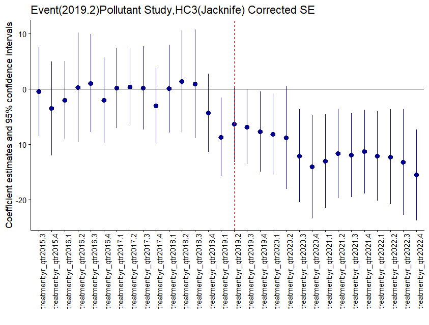

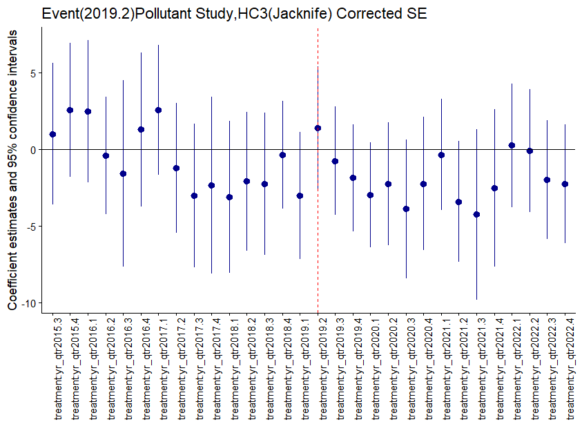

**Methodology**

**Estimators**

The original paper uses HC3 sandwich variance covarience estimators for specification testing, in order to maintain consistency and same evidence weights we are going to use them as our robust variance estimators as well(note that this is a deviation from a pure likelihood approach in TIC and MBIC). We’d incorporate these adjustments via generalized AIC and BIC alternatives. Takeuchi and his criterion is essentially a generalisation of AIC under s model misspecification, instead of asssuming a well specified model under which the bias adjustment to relative likelihood simplifies to 2*number of free parameters.In line with Takeuchis approach we allow the bread and meat of vcov matrix to be unequal and thus use the full trace penalty tr(inv(H)%*%J) where J is the empirical score matrix. Recall that the HC3 vcov estimator is essentially inv(H)%%Omega(HC3)%%inv(H) or B%%M%*%B. Than we can derive a Takeuchi style penalty by multiplying the left side with the inverse of the inverse of the Hessian leading to

$$TIC_{HC3} = -2 \log L(M) + 2
\text{Tr}(\Omega_{HC3} H^{-1})$$
*(by properties of the trace)*

```r
tic_glm <- function(model) {
  ll <- logLik(model)

  # Extract the standard and robust variance-covariance matrices
  H_inv <- vcov(model)
  V_robust <- sandwich::vcovHC(model,type="HC3")

  # Find matching parameters present in both matrices
  common_names <- intersect(rownames(H_inv), rownames(V_robust))

  # Subset both to ensure they are perfectly aligned
  H_inv_sub <- H_inv[common_names, common_names]
  V_robust_sub <- V_robust[common_names, common_names]

  # Alternative to solve(A, B): use %*% directly with H_inv since it is already inverted (H^-1)
  # The trace penalty is trace(H * V_robust). Since vcov() is H^-1, we invert it back:
  H <- solve(H_inv_sub)
  penalty_trace <- sum(diag(H %*% V_robust_sub))

  as.numeric(-2 * ll + 2 * penalty_trace)
}
```

Where the trace penalty are effective degrees of freedom of the model. Misspecified Quasi BIC can be derived analogously by replacing the 2 with log(n) to maintain consistency at larger sample sizes:

$$MBIC_{HC3} = -2 \log L(M) + \log(n)
\text{Tr}(\Omega_{HC3} H^{-1})$$

```r
mbic_glm <- function(model) {
  ll <- logLik(model)

  # Extract the standard and robust variance-covariance matrices
  H_inv <- vcov(model)
  V_robust <- sandwich::vcovHC(model,type="HC3")

  # Find matching parameters present in both matrices
  common_names <- intersect(rownames(H_inv), rownames(V_robust))

  # Subset both to ensure they are perfectly aligned
  H_inv_sub <- H_inv[common_names, common_names]
  V_robust_sub <- V_robust[common_names, common_names]

  # Alternative to solve(A, B): use %*% directly with H_inv since it is already inverted (H^-1)
  # The trace penalty is trace(H * V_robust). Since vcov() is H^-1, we invert it back:
  H <- solve(H_inv_sub)
  penalty_trace <- sum(diag(H %*% V_robust_sub))

  as.numeric(-2 * ll + log(nobs(model)) * penalty_trace)
}
```

When leverage of residuals is low and evenly distributed corresponding to low misspecification the two penalties are very close to AIC and BIC respectively. The two estimators however are robust against heteroskadasticity and retain ability to consistently weight evidence between models with differently misspecified variences.

**Using Information Criteria for (Relative) Likelihoods inference**

**TIC(GIC framework)**

Takeuchis criterion as the generalisation of AIC is the bias adjusted metric for relative information loss between a set of models that occurs when we try and approximate a complex Data Generating process with simplified models estimated from sample models via maximum likelihood. Given that maximised log likelihoods of a set of models is a measure of how probable(or close) data is given a model and penalty term corrects the upward bias of sample estimators its possible to use differences in TICs between two models to estimate Relative Likelihoods that one model is the better approximation to DGP in the following way

$$\text{RelativeLikelihood}(M_2, M_{\min})
= \exp\left(-0.5 \left(TIC_{M_2} - TIC_{\min}\right)\right)$$

Where the change is calculated with respect to the model with the lowest TIC. After we calculate Relative likelihoods for all models in the candidate set we can calculate the Takeuchi/Akaike weight which corresponds to the probability that a given model in the candidate set minimizes information loss/is the best approximation to DGP, and is a ratio of Relative likelihood of Model to lowest TIC model to all other Relative Likelihoods:

$$w_i =
\frac{\text{RL}(M_i)}{\sum_{j=1}^{K} \text{RL}(M_j)}$$

This approach allows one to obtain a full probability distribution of evidence for being the best predictive/approximating model over the entire set of candidate models. The approach is essentially a Relative(to dimension given by parameters) Likelihood ratio approach to inference. Notably the model selected is the best predictive(not necessarily correct) model as we explicitly assume that the true model is too complex to be in the candidate set.This means that with large sample sizes the criterion is more than happy to pick more complex models as long as the signal to noise trade off is favorable and is thus not an asymptotically consistent selection method when the true model is suspected to be in the candidate set. Note also that we are using a sandwich based approximation instead of the true TIC to be in line with the original paper

**MBIC(GBIC framework)**

The log(n) adjustment can be added to the TIC to put it in line with the work of Schwarz on approximate Bayesian model selection.

$$MBIC_{HC3} = -2 \log L(M) + \log(n)
\text{Tr}(\Omega_{HC3} H^{-1})$$

Under the assumption that the true model is in the candidate state and that all models are equally likely prior to observing any data(unit prior), the relative likelihood derived from MBIC is a large sample approximation to the Bayes Factor of two models:

$$\text{RelativeLikelihood}(M_2, M_{\min})
= \exp\left(-0.5 \left(MBIC_{M_2} - MBIC_{\min}\right)\right) =
BF_{2,\min}$$

Given that the Bayes factors is a ratio of posterior probabilities after observing data for same priors, its possible to calculate the posterior probability of a given model given data also known as a Schwarz Weight as:

$$P(M_i \mid \text{Data}) =
\frac{BF_i}{\sum_{j=1}^{K} BF_j}$$

Therefore under the assumption that the true model is in the candidate set and unit priors one can reasonably use Schwarzs approximation with MBIC to make probability statements about plausibility of different models given data, its the most direct substitute for NHST for our purposes. Still these are quasi-posteriors and should be interpreted as plausibility weights at best

**Multimodel approach to evaluating the parallel trends assumption**

What we want to find out is the degree to which the assumption is violated. Given that we use quarterly means this implies that we could have no anticipation, an anticipation of 1-3 quarters, an anticipation of a year, or multi year anticipation which logically implies that the trends diverged long before policy.

For multimodel inference this means restricting the policy effect coefficients to just post policy period, and then estimating models with extra anticipation coefficients for each of 1-4 models, and using the full unrestricted event study model as a stand in for fully non parallel trends. Given that we have a model for each of the possible combinations of the trend regimes it is plausible that the true model is in our candidate set, Schwarz weights are therefore appropriate. Given that we are assuming that each of the regimes is equally likely without observing the data, we are essentially letting the data speak for itself about the relative posterior evidence weight and model uncertainty on a continuous scale. This is the key advantage as we can avoid the Lindley paradox of “accepting the null” of no significant pre trend violations and actually see the embedded uncertainty of our in sample evidence.

Finally, the value of this exercise lies not just in being able to transparently evaluate evidence for effect identification, but also in doing a probabilistic post mortem of sorts on the exact direction and size of bias in our effect estimates for both PM10 and NO2 given that the original paper used the models assuming clean parallel trends. Furthermore, we can also explore how driver behavior adjusted dynamically long before policy implementation.

**Estimation**

We estimate all the models in the candidate set and calculate their TIC scores:

We also calculate their MBIC scores:

```r
tablembic <- t(tibble("unrestrictedtrends"=mbic_glm(eventmodelunrestrict),
                     "1 year anticipation"=mbic_glm(eventmodelant4),
                     "3 quarters anticipation"=mbic_glm(eventmodelant3),
                     "2 quarters anticipation"=mbic_glm(eventmodelant2),
                     "1 quarter anticipation"=mbic_glm(eventmodelant1),
                     " no pre treatment effects"=mbic_glm(eventmodelnull)))
MBICscore <- c(as.numeric(t(tablembic)))
```

We can know use the TIC scores to derive and summarize their Relative Likelihoods and Takeuchi weights for a case in which we don’t assume that the model is in the candidate set:

```r
tabletic <- t(tibble("unrestrictedtrends"=tic_glm(eventmodelunrestrict),
                     "1 year anticipation"=tic_glm(eventmodelant4),
                     "3 quarters anticipation"=tic_glm(eventmodelant3),
                     "2 quarters anticipation"=tic_glm(eventmodelant2),
                     "1 quarter anticipation"=tic_glm(eventmodelant1),
                     " no pre treatment effects"=tic_glm(eventmodelnull)))
TICscore <- c(as.numeric(t(tabletic)))
Model<- c("unrestrictedtrends","1 year anticipation","3 quarters anticipation","2 quarters anticipation","1 quarter anticipation"," no pre treatment effects")
TICch <- TICscore - min(TICscore)
RL <- exp(-0.5*TICch)
Weight <- round(RL/sum(RL),4)
resultsno2tic <- data.frame(
  'Model(J=HC3)' = Model,
  TIC = TICscore,
  Delta = TICch,
  RelLikelihood = RL,
  Weight = Weight,
  check.names = FALSE)
```

Our main table uses the mbic to calculate schwarz posterior probability weights:

```r
MBICch <- MBICscore - min(MBICscore)
BF <- exp(-0.5*MBICch)
PosteriorP <- round(BF/sum(BF),4)
resultsno2mbic <- data.frame(
  'Model(J=HC3)' = Model,
  MBIC = MBICscore,
  Delta = MBICch,
  BayesFactor = BF,
  `P(M|Data)` = PosteriorP, # Backticks allow special characters
  check.names = FALSE)
```

We know rerun the analysis for pm10 to get results for pm10 side of the analysis

**NO2**

```r
gt(resultsno2mbic)
```

| Model(J=HC3) | MBIC | Delta | BayesFactor | P(M\|Data) |
| --- | --- | --- | --- | --- |
| unrestrictedtrends | 2856.566 | 182.1273205 | 2.828491e-40 | 0.0000 |
| 1 year anticipation | 2726.806 | 52.3672988 | 4.251925e-12 | 0.0000 |
| 3 quarters anticipation | 2704.596 | 30.1565295 | 2.828739e-07 | 0.0000 |
| 2 quarters anticipation | 2674.439 | 0.0000000 | 1.000000e+00 | 0.5280 |
| 1 quarter anticipation | 2674.665 | 0.2254438 | 8.933991e-01 | 0.4717 |
| no pre treatment effects | 2689.748 | 15.3084747 | 4.740312e-04 | 0.0003 |

```r
gt(resultsno2tic)
```

| Model(J=HC3) | TIC | Delta | RelLikelihood | Weight |
| --- | --- | --- | --- | --- |
| unrestrictedtrends | 2506.016 | 52.187868 | 4.651023e-12 | 0.0000 |
| 1 year anticipation | 2469.457 | 15.629173 | 4.038017e-04 | 0.0003 |
| 3 quarters anticipation | 2463.176 | 9.348153 | 9.334140e-03 | 0.0078 |
| 2 quarters anticipation | 2453.828 | 0.000000 | 1.000000e+00 | 0.8346 |
| 1 quarter anticipation | 2457.166 | 3.337935 | 1.884415e-01 | 0.1573 |
| no pre treatment effects | 2475.713 | 21.884910 | 1.769100e-05 | 0.0000 |

**PM10**

```r
gt(resultspm10mbic)
```

| Model(J=HC3) | MBIC | Delta | BayesFactor | P(M\|Data) |
| --- | --- | --- | --- | --- |
| unrestrictedtrends | 2447.128 | 82.606344 | 1.154145e-18 | 0.0000 |
| 1 year anticipation | 2380.675 | 16.153208 | 3.107245e-04 | 0.0002 |
| 3 quarters anticipation | 2375.499 | 10.977479 | 4.133050e-03 | 0.0030 |
| 2 quarters anticipation | 2369.113 | 4.591336 | 1.006941e-01 | 0.0735 |
| 1 quarter anticipation | 2367.179 | 2.657455 | 2.648140e-01 | 0.1933 |
| no pre treatment effects | 2364.522 | 0.000000 | 1.000000e+00 | 0.7300 |

```r
gt(resultspm10tic)
```

| Model(J=HC3) | TIC | Delta | RelLikelihood | Weight |
| --- | --- | --- | --- | --- |
| unrestrictedtrends | 2169.023 | 11.8545461 | 0.002665741 | 0.0009 |
| 1 year anticipation | 2159.776 | 2.6071060 | 0.271565211 | 0.0883 |
| 3 quarters anticipation | 2158.922 | 1.7537533 | 0.416080453 | 0.1353 |
| 2 quarters anticipation | 2157.800 | 0.6317395 | 0.729154400 | 0.2371 |
| 1 quarter anticipation | 2157.169 | 0.0000000 | 1.000000000 | 0.3252 |
| no pre treatment effects | 2158.013 | 0.8439356 | 0.655755151 | 0.2132 |

The approximate posterior weights are spread out in such a way that the clean DiD model is 2.68 times more likely than the anticipation models. The noise in PM10 data is likely such that the models cannot pick up any meaningful divergence between the treatment and control under the approximately true DGP assumption. This aligns with the conclusions of the original paper - the volume effect which would have affected PM10 more through the decrease in the total number of cars on the road was relatively modest, with people acquiring cleaner vehicles but largely leaving their driving habits unchanged.

**Takeuchi and Akaike vs Schwarz and Bayes and GIC vs GBIC**

Ultimately whether one should choose the relative information loss or posterior probability interpretation of the analysis outcome boils down to whether one thinks the mean is well specified(additive and linear) or misspespecified (which is most likely). I tend to err on the side of caution and use both and interpret both jointly even if they come from two competing philosophies. Still the relative evidence approach does help hint towards most plausible anticipation patterns in NO2 which are economically meaningful if DGP assumption holds and at least provides us with the decent enough representation of inherent in sample uncertainty if it doesn’t.

**Bonus:Bayesian Model Averages of the Anticipation Adjusted Effects to put a number on attenuation bias**

NO2: Post‑policy ATT by Model with HC3 variences

| Model | ATT | VAR |
| --- | --- | --- |
| unrestricted | −2.292 | 2.6542499 |
| 1 year anticipation | −10.261 | 0.7714553 |
| 3 quarters anticipation | −10.425 | 0.7644262 |
| 2 quarters anticipation | −10.532 | 0.7665021 |
| 1 quarter anticipation | −10.272 | 0.7311806 |
| no pre treatment effects | −9.768 | 0.7239094 |

PM₁₀: Post‑policy ATT by Model with HC3 variences

| Model | ATT | VAR |
| --- | --- | --- |
| unrestricted | 1.2039 | 2.1086 |
| 1 year anticipation | −1.6237 | 0.4334 |
| 3 quarters anticipation | −1.4682 | 0.4076 |
| 2 quarters anticipation | −1.2908 | 0.3926 |
| 1 quarter anticipation | −1.3045 | 0.3532 |
| no pre treatment effects | −1.1083 | 0.3300 |

```r
gt(data.frame(NO2BAME=sum(resultsno2mbic$`P(M|Data)`*no2_att$ATT),
NO2BAMEtic=sum(resultsno2tic$Weight*no2_att$ATT),
PM10BAME=sum(resultspm10mbic$`P(M|Data)`*pm10_att$ATT),
PM10BAMEtic=sum(resultspm10tic$Weight*pm10_att$ATT)))
```

| NO2BAME | NO2BAMEtic | PM10BAME | PM10BAMEtic |
| --- | --- | --- | --- |
| -10.4094 | -10.49054 | -1.160855 | -1.307499 |

```r
# 1. Compute the Point Estimates first
no2_bma_m  <- sum(resultsno2mbic$`P(M|Data)` * no2_att$ATT);
no2_bma_t  <- sum(resultsno2tic$Weight * no2_att$ATT);
pm10_bma_m <- sum(resultspm10mbic$`P(M|Data)` * pm10_att$ATT);
pm10_bma_t <- sum(resultspm10tic$Weight * pm10_att$ATT);

# 2. Compute the Standard Errors using the Law of Total Variance
no2_se_m  <- sqrt(sum(resultsno2mbic$`P(M|Data)` * (no2_att$VAR + (no2_att$ATT - no2_bma_m)^2)));
no2_se_t  <- sqrt(sum(resultsno2tic$Weight * (no2_att$VAR + (no2_att$ATT - no2_bma_t)^2)));
pm10_se_m <- sqrt(sum(resultspm10mbic$`P(M|Data)` * (pm10_att$VAR + (pm10_att$ATT - pm10_bma_m)^2)));
pm10_se_t <- sqrt(sum(resultspm10tic$Weight * (pm10_att$VAR + (pm10_att$ATT - pm10_bma_t)^2)));

# 3. Present cleanly side-by-side using gt
gt(data.frame(
  Metric      = c("BMA Estimate", "Standard Error"),
  NO2_MBIC    = c(no2_bma_m, no2_se_m),
  NO2_TIC     = c(no2_bma_t, no2_se_t),
  PM10_MBIC   = c(pm10_bma_m, pm10_se_m),
  PM10_TIC    = c(pm10_bma_t, pm10_se_t)
))
```

| Metric | NO2_MBIC | NO2_TIC | PM10_MBIC | PM10_TIC |
| --- | --- | --- | --- | --- |
| BMA Estimate | -10.4094016 | -10.4905413 | -1.1608548 | -1.3074992 |
| Standard Error | 0.8756876 | 0.8774664 | 0.5889994 | 0.6325832 |